# Multi-cue recall with single-cue pre-test (v5.0)

## Probability of remembering first word

First the main results: predicting behavior in the multi-cue trials from behavior in the single-cue trials. We’ll start by using the same memory strength index as we used for the 2AFC version: mean log reaction time, excluding the first round. As a sanity check, we first ask if our memory strength index predicts participants choices about which image to recall.

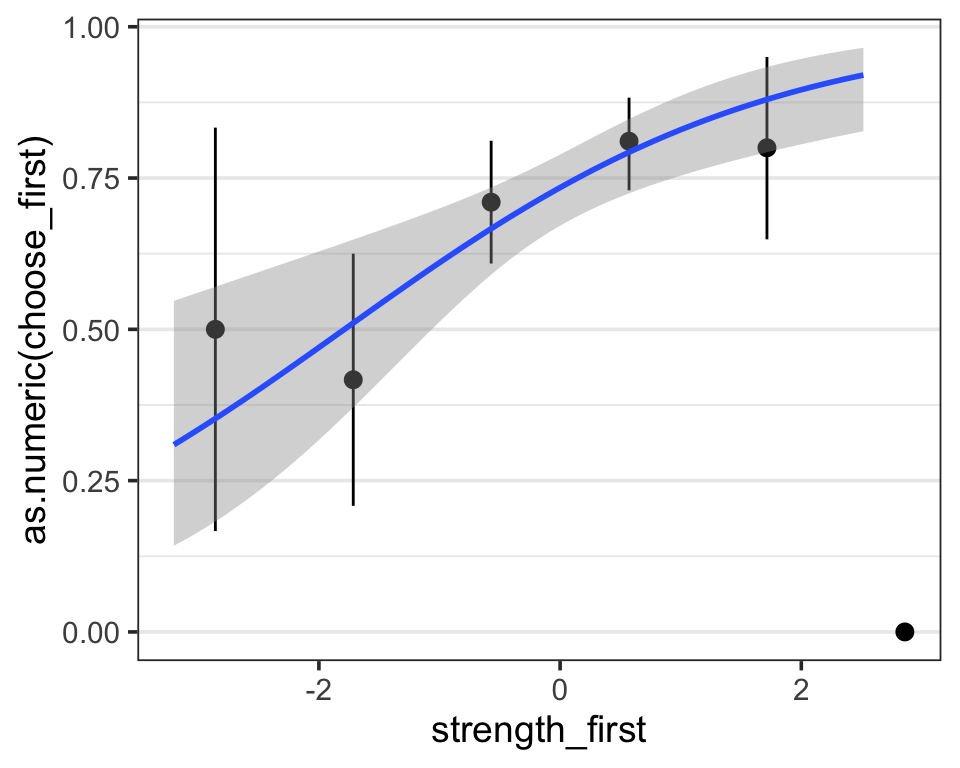

```r
X = multi %>% add_strength(round > 1, -log(rt))

X %>% ggplot(aes(strength_first, as.numeric(choose_first))) +
    stat_summary_bin(fun.data=mean_cl_boot, bins=5) +
    geom_smooth(method = "glm", method.args = list(family = "binomial"), formula=y~x)
```

```r
lmer(choose_first ~ strength_first + (strength_first|wid), data=X) %>% summ
```

| Fixed Effects | Fixed Effects Est. | Fixed Effects S.E. | Fixed Effects t val. | Fixed Effects d.f. | Fixed Effects p |
| --- | --- | --- | --- | --- | --- |
| (Intercept) | 0.728 | 0.046 | 15.811 | 27.509 | 0.000 |
| strength_first | 0.107 | 0.034 | 3.177 | 22.043 | 0.004 |

p values calculated using Satterthwaite d.f.

It does.

## Proportion presentation time

The simplest test of rational memory: do people spend more time looking at the cue that they have a stronger memory of? This plot only considers trials where both cues are seen.

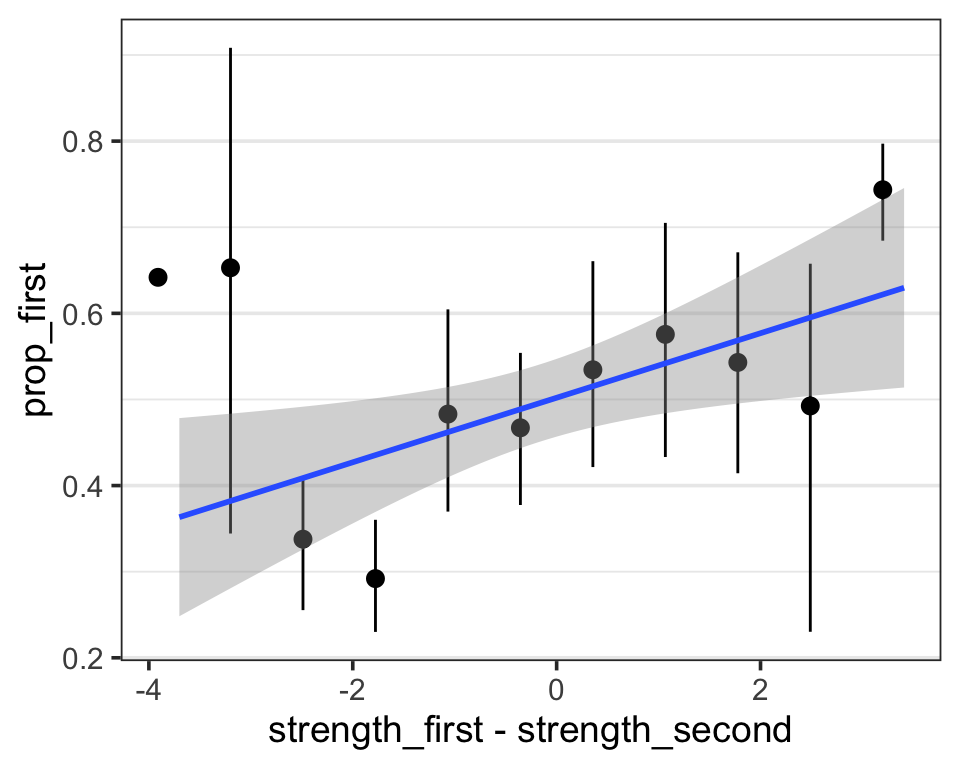

```r
X = multi %>%
    filter(n_pres >= 2) %>%
    add_strength(round > 1, -log(rt))

X %>% ggplot(aes(strength_first - strength_second, prop_first)) +
    stat_summary_bin(fun.data=mean_cl_boot, bins=10) +
    geom_smooth(method='lm')
```

```r
X %>% lmer(prop_first ~ rel_strength + (rel_strength|wid), data=.) %>% summ
```

| Fixed Effects | Fixed Effects Est. | Fixed Effects S.E. | Fixed Effects t val. | Fixed Effects d.f. | Fixed Effects p |
| --- | --- | --- | --- | --- | --- |
| (Intercept) | 0.519 | 0.031 | 16.944 | 18.760 | 0.000 |
| rel_strength | 0.042 | 0.018 | 2.356 | 11.201 | 0.038 |

p values calculated using Satterthwaite d.f.

```r
X %>% lmer(prop_first ~ strength_first + strength_second + (strength_first + strength_second|wid), data=.) %>% summ
```

| Fixed Effects | Fixed Effects Est. | Fixed Effects S.E. | Fixed Effects t val. | Fixed Effects d.f. | Fixed Effects p |
| --- | --- | --- | --- | --- | --- |
| (Intercept) | 0.515 | 0.031 | 16.605 | 17.536 | 0.000 |
| strength_first | 0.033 | 0.026 | 1.263 | 15.134 | 0.226 |
| strength_second | -0.050 | 0.023 | -2.240 | 40.816 | 0.031 |

p values calculated using Satterthwaite d.f.

Looks pretty good! The coefficient on `rel_strength` was .041 in the last experiment (with strength in a 2AFC task).

## Using accuracy in the score

Giving a correct response is much more informative in cued-recall than in 2AFC. Can we improve our prediction by incorporating accuracy into the strength index?

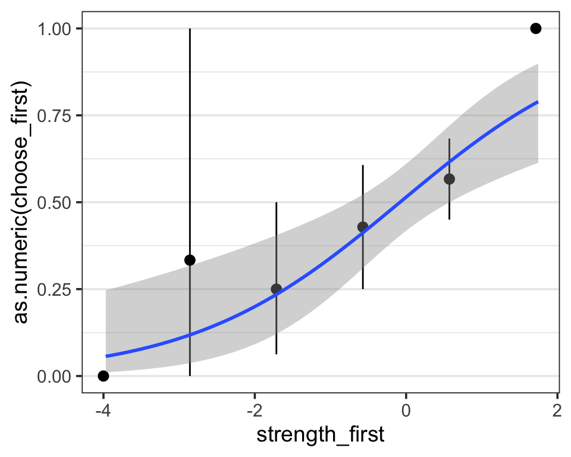

```r
X2 = multi %>%
    filter(n_pres >= 2) %>%
    add_strength(round > 1, 2 * correct -log(rt))

X2 %>% ggplot(aes(strength_first, as.numeric(choose_first))) +
    stat_summary_bin(fun.data=mean_cl_boot, bins=5) +
    geom_smooth(method = "glm", method.args = list(family = "binomial"), formula=y~x)
```

```r
lmer(choose_first ~ strength_first + (strength_first|wid), data=X2) %>% summ
```

| Fixed Effects | Fixed Effects Est. | Fixed Effects S.E. | Fixed Effects t val. | Fixed Effects d.f. | Fixed Effects p |
| --- | --- | --- | --- | --- | --- |
| (Intercept) | 0.519 | 0.052 | 10.057 | 19.052 | 0.000 |
| strength_first | 0.145 | 0.039 | 3.718 | 79.338 | 0.000 |

p values calculated using Satterthwaite d.f.

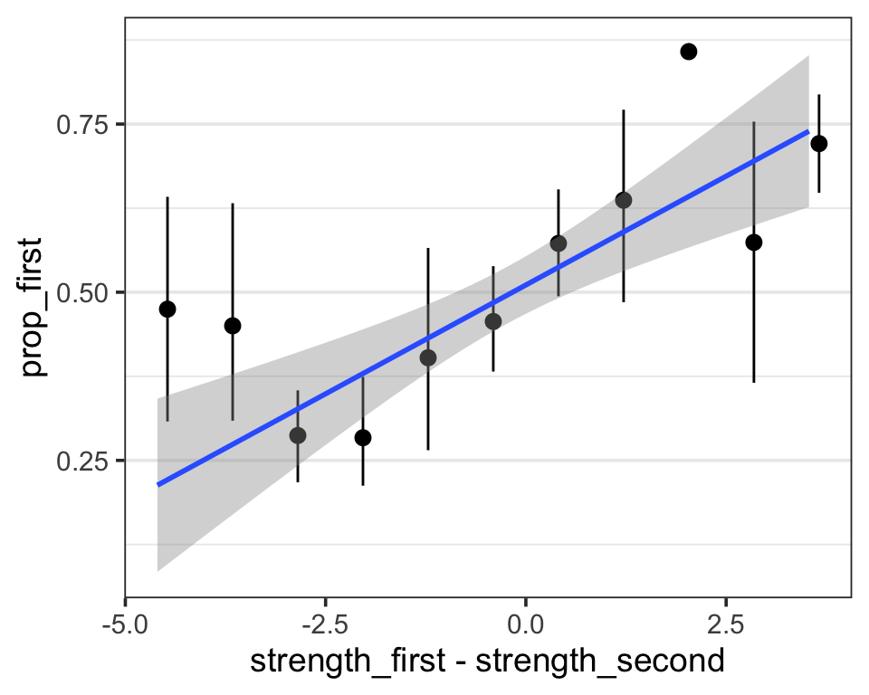

```r
X2 %>% ggplot(aes(strength_first - strength_second, prop_first)) +
    stat_summary_bin(fun.data=mean_cl_boot, bins=10) +
    geom_smooth(method='lm')
```

```r
X2 %>% lmer(prop_first ~ rel_strength + (rel_strength|wid), data=.) %>% summ
```

| Fixed Effects | Fixed Effects Est. | Fixed Effects S.E. | Fixed Effects t val. | Fixed Effects d.f. | Fixed Effects p |
| --- | --- | --- | --- | --- | --- |
| (Intercept) | 0.534 | 0.031 | 17.296 | 16.954 | 0.000 |
| rel_strength | 0.074 | 0.016 | 4.694 | 13.924 | 0.000 |

p values calculated using Satterthwaite d.f.

```r
X2 %>% lmer(prop_first ~ strength_first + strength_second + (strength_first + strength_second|wid), data=.) %>% summ
```

| Fixed Effects | Fixed Effects Est. | Fixed Effects S.E. | Fixed Effects t val. | Fixed Effects d.f. | Fixed Effects p |
| --- | --- | --- | --- | --- | --- |
| (Intercept) | 0.511 | 0.030 | 16.773 | 17.431 | 0.000 |
| strength_first | 0.054 | 0.022 | 2.484 | 14.370 | 0.026 |
| strength_second | -0.096 | 0.021 | -4.620 | 16.031 | 0.000 |

p values calculated using Satterthwaite d.f.

```r
multi = multi %>% add_strength(round > 1, 2 * correct -log(rt))
```

We sure can, by a substantial amount. Relationship between `rel_strength` and `prop_first` is almost twice as strong!

For the rest of the analyses, we will use this new and improved index.

## First presentation duration

As we saw in my paper on fixations in simple choice, total presentation time can be a slightly tricky measure becuase recall cuts off the final fixation/presentation. The duration of the first presentation is potentially a more reliable cue.

Consider only the trials with more than one presentation. Do participants switch away from the first image more quickly when they have a worse memory of it?

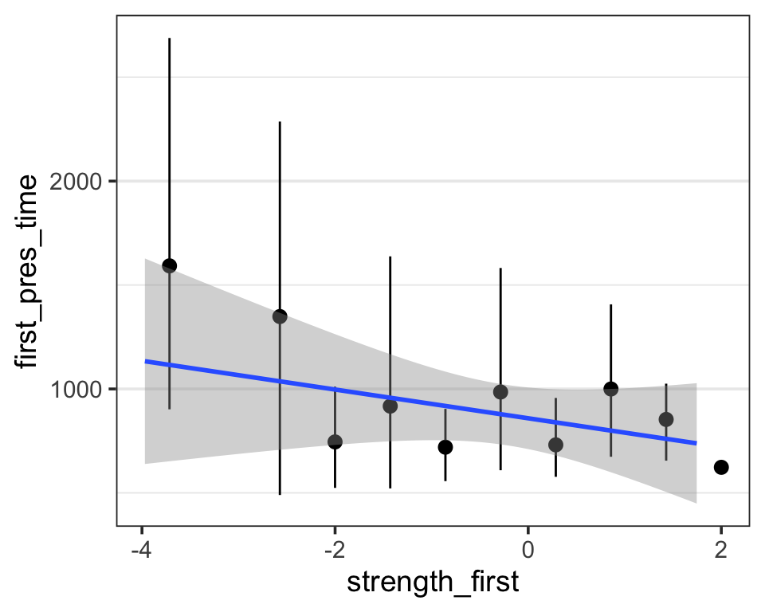

```r
X = multi %>%
    filter(n_pres > 1)

X %>% ggplot(aes(strength_first, first_pres_time)) +
    stat_summary_bin(fun.data=mean_cl_boot, bins=10) +
    geom_smooth(method='lm')
```

```r
X %>% lmer(first_pres_time ~ strength_first + (strength_first|wid), data=.) %>% summ
```

| Fixed Effects | Fixed Effects Est. | Fixed Effects S.E. | Fixed Effects t val. | Fixed Effects d.f. | Fixed Effects p |
| --- | --- | --- | --- | --- | --- |
| (Intercept) | 980.546 | 112.780 | 8.694 | 7.109 | 0.000 |
| strength_first | -33.346 | 63.395 | -0.526 | 76.583 | 0.600 |

p values calculated using Satterthwaite d.f.

Looks bad. Note that the negative relationship in the plotted fixed effects regression doesn’t hold up with random effects.

## Second presentation duration

We can do a similar analysis for the second presentation duration. In this case, however, the duration may depend on the strength of both the first and second cues.

### Second-seen strength

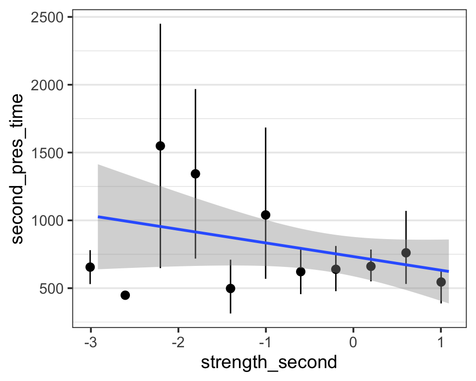

```r
X = multi %>%
    filter(n_pres > 2) %>%
    mutate(second_pres_time = map_dbl(presentation_times, 2, .default=NaN))

X %>% ggplot(aes(strength_second, second_pres_time)) +
    stat_summary_bin(fun.data=mean_cl_boot, bins=10) +
    geom_smooth(method='lm')
```

```r
X %>% lmer(second_pres_time ~ strength_second + (1|wid), data=.) %>% summ
```

| Fixed Effects | Fixed Effects Est. | Fixed Effects S.E. | Fixed Effects t val. | Fixed Effects d.f. | Fixed Effects p |
| --- | --- | --- | --- | --- | --- |
| (Intercept) | 863.780 | 142.883 | 6.045 | 9.601 | 0.000 |
| strength_second | -53.789 | 57.594 | -0.934 | 42.823 | 0.356 |

p values calculated using Satterthwaite d.f.

Ooof.

### First-seen strength

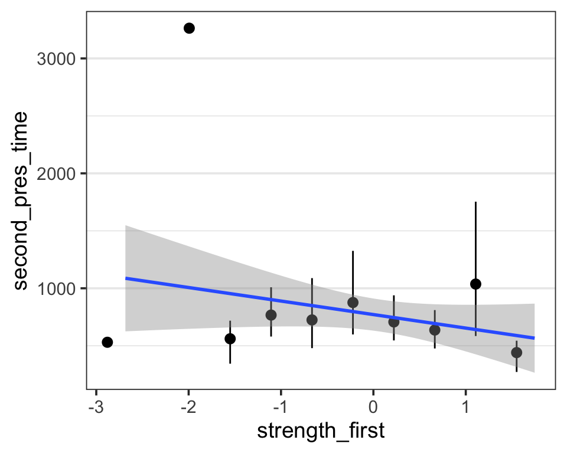

```r
X %>% ggplot(aes(strength_first, second_pres_time)) +
    stat_summary_bin(fun.data=mean_cl_boot, bins=10) +
    geom_smooth(method='lm')
```

```r
X %>% lmer(second_pres_time ~ strength_first + (strength_first|wid), data=.) %>% summ
```

| Fixed Effects | Fixed Effects Est. | Fixed Effects S.E. | Fixed Effects t val. | Fixed Effects d.f. | Fixed Effects p |
| --- | --- | --- | --- | --- | --- |
| (Intercept) | 833.535 | 103.757 | 8.034 | 6.729 | 0.000 |
| strength_first | -143.264 | 116.414 | -1.231 | 11.561 | 0.243 |

p values calculated using Satterthwaite d.f.

This one is in the right direction at least.

### Relative strength (first - second)

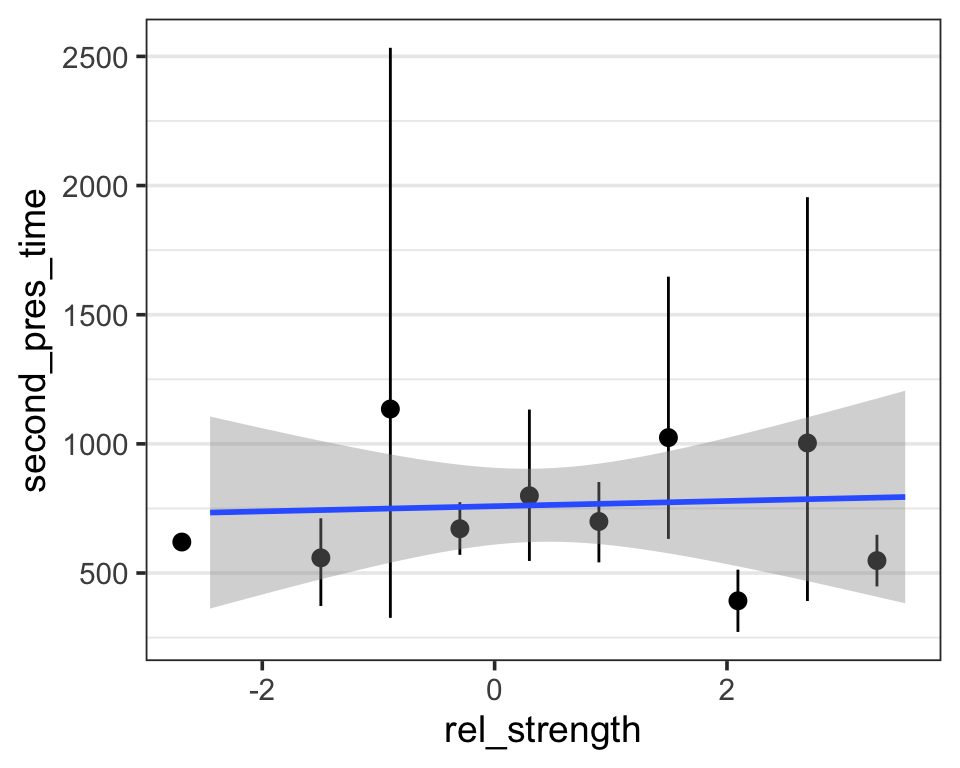

```r
X %>% ggplot(aes(rel_strength, second_pres_time)) +
    stat_summary_bin(fun.data=mean_cl_boot, bins=10) +
    geom_smooth(method='lm')
```

```r
X %>% lmer(second_pres_time ~ rel_strength + (rel_strength|wid), data=.) %>% summ
```

| Fixed Effects | Fixed Effects Est. | Fixed Effects S.E. | Fixed Effects t val. | Fixed Effects d.f. | Fixed Effects p |
| --- | --- | --- | --- | --- | --- |
| (Intercept) | 760.833 | 97.867 | 7.774 | 9.659 | 0.000 |
| rel_strength | 8.341 | 115.072 | 0.072 | 8.688 | 0.944 |

p values calculated using Satterthwaite d.f.

Yeah there’s nothing here. Note that the results are even worse if we use the plain log RT strength index.

## Single-cue recall basics

### Accuracy

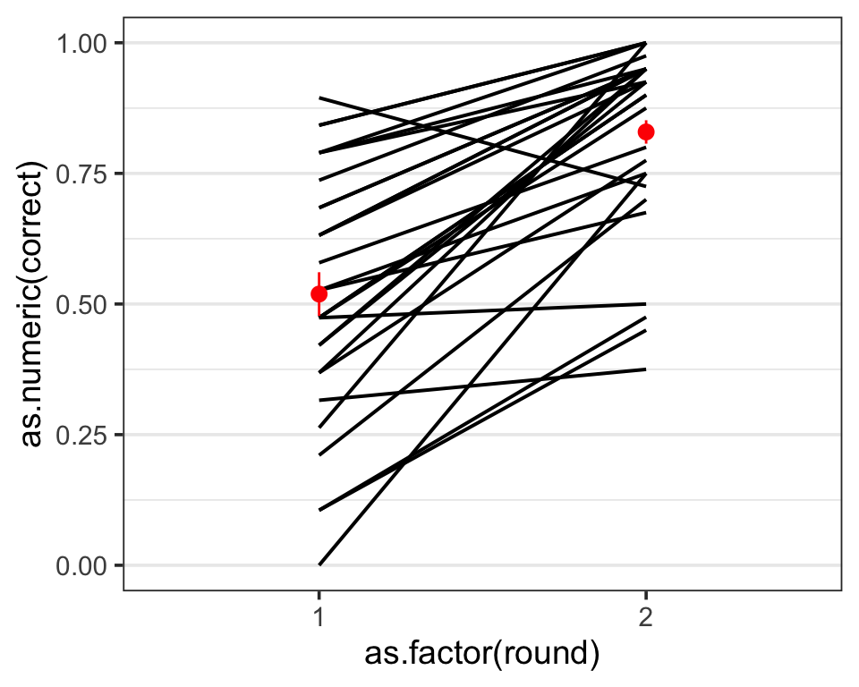

```r
simple %>% ggplot(aes(as.factor(round), as.numeric(correct))) +
    stat_summary(aes(group=wid), fun.data=mean_cl_boot, geom="line", size=0.7) +
    stat_summary(fun.data=mean_cl_boot, color="red")
```

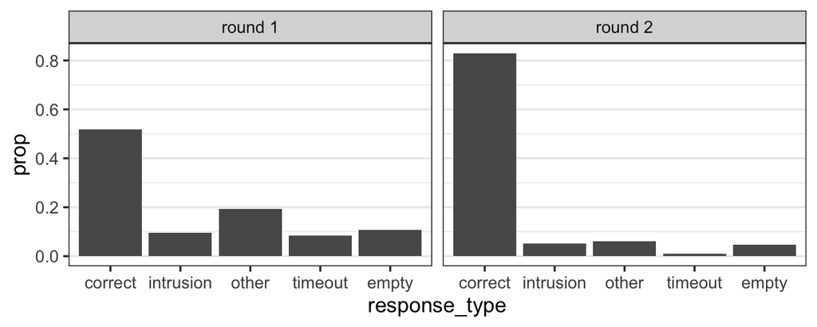

```r
simple %>% ggplot(aes(response_type, y = ..prop.., group=0)) +
    geom_bar() + facet_wrap(~round, labeller=label_glue("round {round}"))
```

### RT

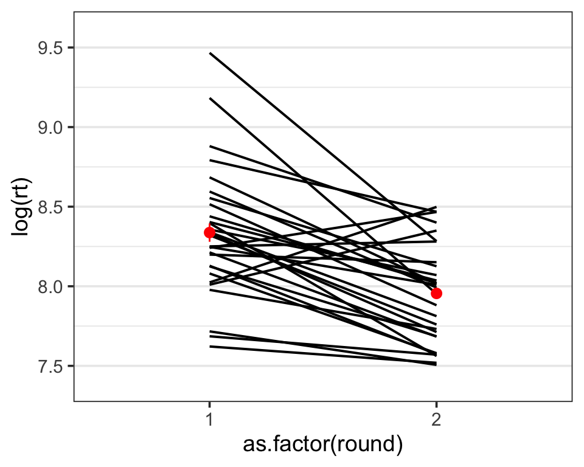

```r
simple %>% ggplot(aes(as.factor(round), log(rt))) +
    stat_summary(aes(group=wid), fun.data=mean_cl_boot, geom="line", size=0.7) +
    stat_summary(fun.data=mean_cl_boot, color="red")
```

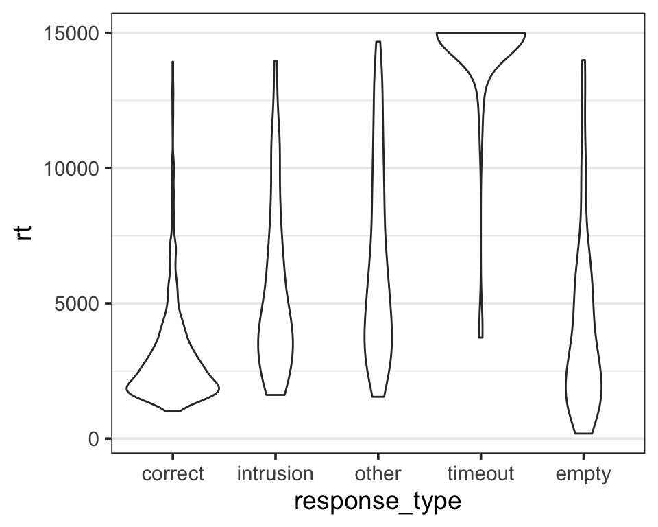

```r
simple %>% ggplot(aes(response_type, rt)) +
    geom_violin()
```

## RT Correlations

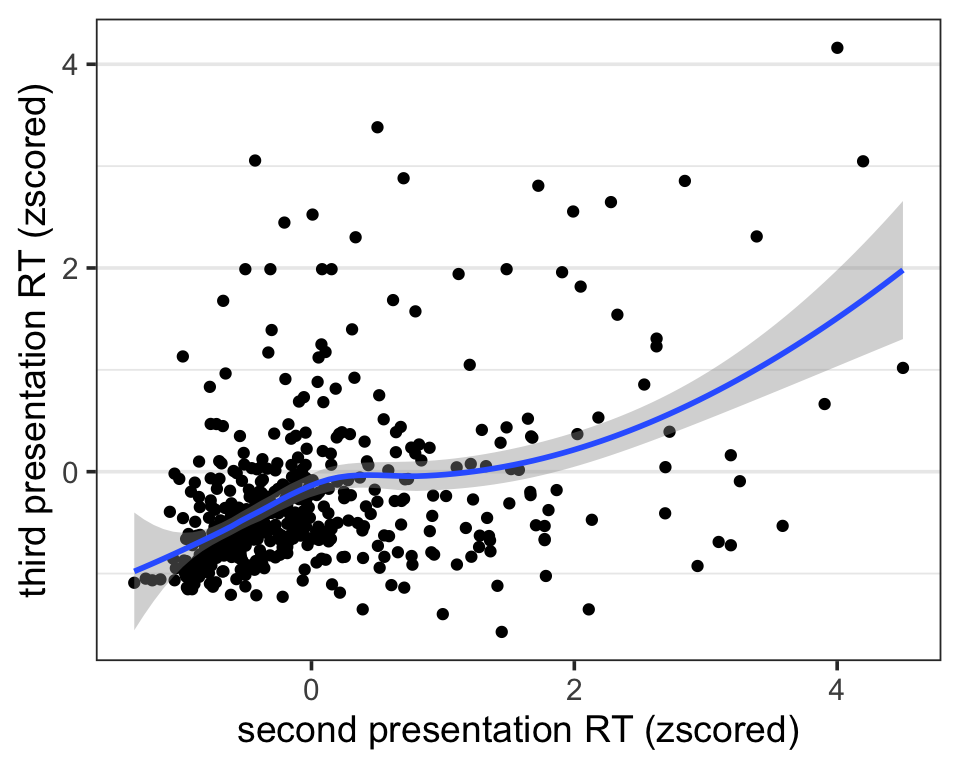

```r
X = simple %>%
    mutate(presentation = (trial_num-1) %/% 20 + 1) %>%
    mutate(rt_z = scale(rt)) %>%
    select(wid, word, rt_z, presentation) %>%
    pivot_wider(names_from=presentation, values_from=rt_z, names_prefix="rt_z") %>%
    ungroup()

X %>% ggplot(aes(rt_z2, rt_z3)) + geom_point() + geom_smooth() +
    labs(x="second presentation RT (zscored)", y="third presentation RT (zscored)")
```

```r
with(X, cor(X %>% select(3:5), use='comp'))
```

```
##            rt_z1      rt_z2     rt_z3
## rt_z1 1.00000000 0.06137526 0.0825041
## rt_z2 0.06137526 1.00000000 0.4489407
## rt_z3 0.08250410 0.44894066 1.0000000
```

## Accuracy Correlations

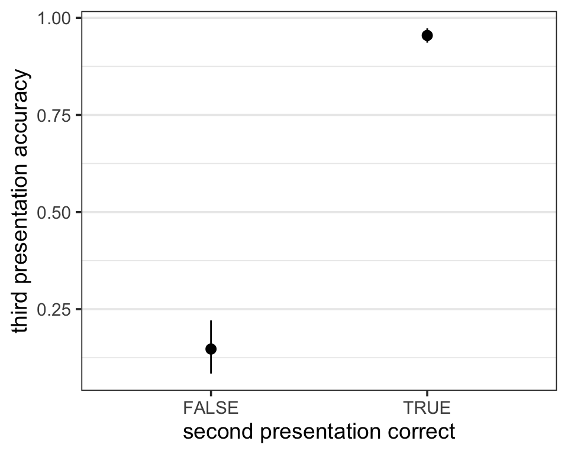

```r
X = simple %>%
    mutate(presentation = (trial_num-1) %/% 20 + 1) %>%
    select(wid, word, correct, presentation) %>%
    pivot_wider(names_from=presentation, values_from=correct, names_prefix="correct") %>%
    ungroup()

X %>% ggplot(aes(correct2, as.numeric(correct3))) + stat_summary(fun.data=mean_cl_boot) +
    labs(x="second presentation correct", y="third presentation accuracy")
```

```r
with(X, cor(X %>% select(3:5), use='comp'))
```

```
##           correct1  correct2  correct3
## correct1 1.0000000 0.4066632 0.3760898
## correct2 0.4066632 1.0000000 0.7866338
## correct3 0.3760898 0.7866338 1.0000000
```

## Joint Correlations

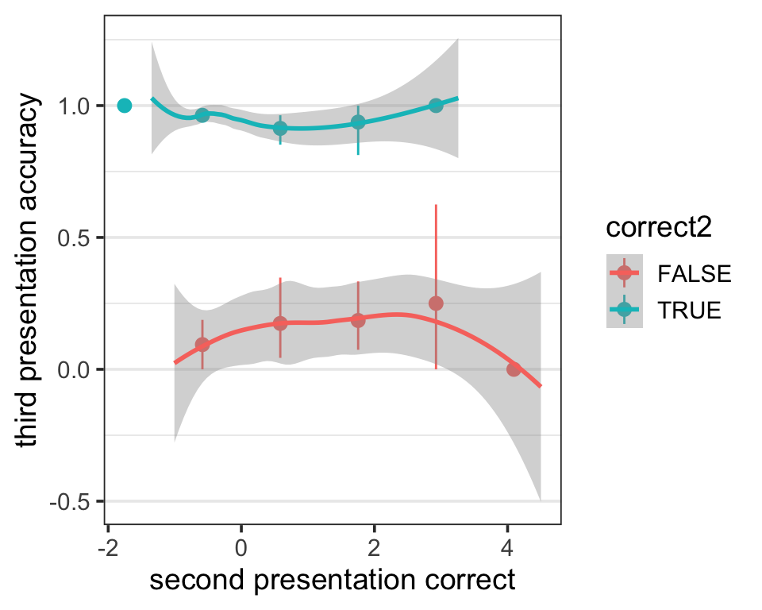

```r
rt = simple %>%
    mutate(presentation = (trial_num-1) %/% 20 + 1) %>%
    mutate(rt_z = scale(rt)) %>%
    select(wid, word, rt_z, presentation) %>%
    pivot_wider(names_from=presentation, values_from=rt_z, names_prefix="rt_z") %>%
    ungroup()

choice = simple %>%
    mutate(presentation = (trial_num-1) %/% 20 + 1) %>%
    select(wid, word, correct, presentation) %>%
    pivot_wider(names_from=presentation, values_from=correct, names_prefix="correct") %>%
    ungroup()

both = inner_join(rt, choice)

both %>% ggplot(aes(rt_z2, as.numeric(correct3), color=correct2)) +
    stat_summary_bin(fun.data=mean_cl_boot, bins=5) +
    geom_smooth() +
    labs(x="second presentation correct", y="third presentation accuracy")
```

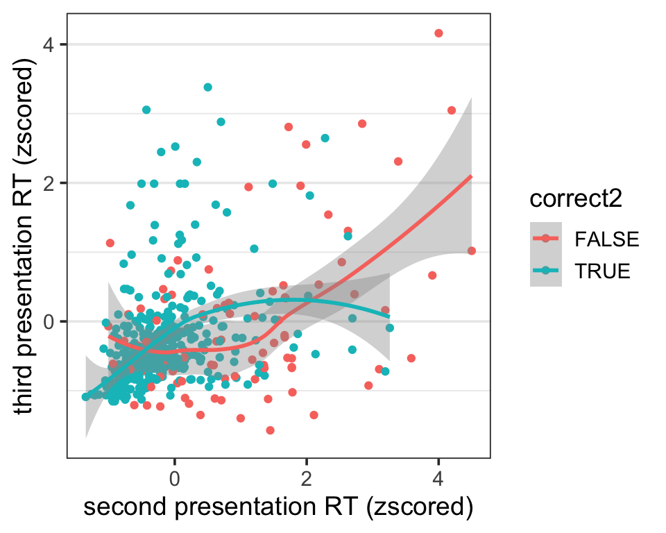

```r
both %>% ggplot(aes(rt_z2, rt_z3, color=correct2)) + geom_point() + geom_smooth() +
    labs(x="second presentation RT (zscored)", y="third presentation RT (zscored)")
```

```r
# both %>% ggplot(aes(rt_z2, rt_z3, color=interaction(correct2, correct3))) +
#     geom_smooth() +
#     labs(x="second presentation RT (zscored)", y="third presentation RT (zscored)"
```

This last one is potentially worth thinking more about. Does this suggest that we should be using an interaction between accuracy and RT to measure memory strength?